# Modeling Trail Visits

2022-05-27

This page shows our initial work with modeling counts of visits using information from the original trails dataset as well as weather data we merged in. The idea is to create predicted counts of trail visits in post-fire years that give us a sense of “what would visits have been like, given the weather and time of year, had the fire not happened.” Then, we can compare this baseline predicted estimate to what actually happened after the fire to get a sense of how the fire changed things.

## Load in data

First, load in the trails data and the climate data from NOAA: https://www.ncdc.noaa.gov/cdo-web/. We pulled climate data from on the “CASCADE LOCKS, OR” weather station (GHCND:USC00351407). This is very close to the area of the trails.

```r
setwd("C:/Users/stlp/Dropbox/Classes/SP 22/CSE 512/final")
v <- read.csv("monthly_vis_by_site_zeroed.csv")
# clean visit data to drop incorrect observation from 2016:

v <- v[!(v$month==9 & v$year==2016 & v$years_fire==-2),]
c <- read.csv("climate.csv")
```

## Clean climate data and extract relevant variables

```r
c.a <- c %>%
  mutate(dstr = as.character(DATE)) %>%
  separate(dstr, into=c("year", "month"), sep="-") %>%
  mutate(month = as.numeric(month)) %>%
  select(year, month, TMIN, TMAX, SNOW, PRCP, TAVG)
```

Key variables in the climate data:

- TMIN = average of daily minimum temperature across the month, in Fahrenheit
- TMAX = average of daily maximum temperature across the month, in Fahrenheit
- SNOW = total monthly snowfall (inches)
- PRCP = total monthly precipitation (inches)
- TAVG = average temperature across the month

## Merge climate data to trails data

```r
vc <- merge(v, c.a, by=c("month", "year"), all.x=TRUE)
```

## Test out Poisson models for visit counts

First, create analytic dataset. We’re only using pre-fire data and will convert years and months to factors rather than estimating linear effects across month/year.

```r
vc.a <- vc %>%
  filter(pre_post_fire=="pre") %>%
  mutate(year=as.factor(year),
         month = as.factor(month),
         Name = as.factor(Name))
```

First, fit a model with only: year indicators, month indicators, and trail indicators.

```r
m1 <- glm(tot_vis ~ year + month + Name,
          vc.a,
          family=poisson)

summary(m1)
```

```
##
## Call:
## glm(formula = tot_vis ~ year + month + Name, family = poisson,
##     data = vc.a)
##
## Deviance Residuals:
##     Min       1Q   Median       3Q      Max
## -61.006   -5.061    0.708    5.008  137.270
##
## Coefficients:
##                                         Estimate Std. Error  z value Pr(>|z|)
## (Intercept)                             4.936318   0.010057  490.848   <2e-16
## year2015                                0.678087   0.006554  103.461   <2e-16
## year2016                                1.286022   0.006434  199.873   <2e-16
## year2017                                1.482000   0.006644  223.071   <2e-16
## month2                                  0.380778   0.009184   41.462   <2e-16
## month3                                  1.108650   0.008163  135.808   <2e-16
## month4                                  1.704867   0.007695  221.553   <2e-16
## month5                                  2.335294   0.007413  315.021   <2e-16
## month6                                  2.611065   0.007334  356.028   <2e-16
## month7                                  2.598084   0.007337  354.100   <2e-16
## month8                                  2.442909   0.007380  331.032   <2e-16
## month9                                  1.977352   0.007888  250.679   <2e-16
## month10                                 1.253445   0.008567  146.309   <2e-16
## month11                                 0.852633   0.009170   92.980   <2e-16
## month12                                 0.345332   0.010271   33.622   <2e-16
## NameBeacon Rock                        -0.417457   0.005106  -81.765   <2e-16
## NameCape Horn                          -1.133735   0.006521 -173.871   <2e-16
## NameCatherine Creek area               -2.281900   0.010571 -215.860   <2e-16
## NameCherry Orchard FCG trail           -3.533852   0.019104 -184.980   <2e-16
## NameCoyote Wall area                   -2.151021   0.009966 -215.846   <2e-16
## NameCrawford Oaks WDNR                 -3.045838   0.015101 -201.704   <2e-16
## NameDog Creek Falls                    -3.084449   0.015382 -200.527   <2e-16
## NameDog Mountain/Augspurger Mtn        -0.576157   0.005364 -107.417   <2e-16
## NameDog River                          -3.216043   0.016383 -196.299   <2e-16
## NameEagle Creek                         0.256660   0.004285   59.899   <2e-16
## NameEight Mile trail                   -3.120381   0.015648 -199.405   <2e-16
## NameFalls Creek Falls                  -1.207024   0.006705 -180.006   <2e-16
## NameHerman Creek                       -2.250852   0.010424 -215.938   <2e-16
## NameHorsetail Creek                    -2.803293   0.013459 -208.283   <2e-16
```

[output cut: 77 more lines]

```
## NameUmbrella/Sahalie Falls             ***
## NameWahkeena Falls                     ***
## NameWashougal River area               ***
## NameWeldon Wagon Rd Trail              ***
## NameWind Mountain                      ***
## ---
## Signif. codes:  0 '***' 0.001 '**' 0.01 '*' 0.05 '.' 0.1 ' ' 1
##
## (Dispersion parameter for poisson family taken to be 1)
##
##     Null deviance: 3086486  on 1475  degrees of freedom
## Residual deviance:  196786  on 1421  degrees of freedom
## AIC: 207909
##
## Number of Fisher Scoring iterations: 5
```

This output is a bit chaotic due to the trail fixed effects, but you can get the general idea.

Next, fit a model including some of the climate variables.

```r
m2 <- glm(tot_vis ~ year + month + Name + TAVG + PRCP,
          vc.a,
          family=poisson)

summary(m2)
```

```
##
## Call:
## glm(formula = tot_vis ~ year + month + Name + TAVG + PRCP, family = poisson,
##     data = vc.a)
##
## Deviance Residuals:
##     Min       1Q   Median       3Q      Max
## -64.137   -5.212    0.811    5.060  138.768
##
## Coefficients:
##                                          Estimate Std. Error  z value Pr(>|z|)
## (Intercept)                             4.9439277  0.0254141  194.535   <2e-16
## year2015                                0.7078437  0.0066002  107.245   <2e-16
## year2016                                1.3609153  0.0066883  203.478   <2e-16
## year2017                                1.5980960  0.0069666  229.395   <2e-16
## month2                                  0.4493979  0.0108371   41.469   <2e-16
## month3                                  1.1965798  0.0119733   99.937   <2e-16
## month4                                  1.4734128  0.0122714  120.068   <2e-16
## month5                                  1.9406217  0.0145837  133.068   <2e-16
## month6                                  2.1917823  0.0175973  124.552   <2e-16
## month7                                  2.0704624  0.0194696  106.343   <2e-16
## month8                                  1.8988533  0.0205972   92.190   <2e-16
## month9                                  1.5661264  0.0160312   97.693   <2e-16
## month10                                 1.2990808  0.0157379   82.545   <2e-16
## month11                                 0.8895578  0.0120616   73.751   <2e-16
## month12                                 0.5923569  0.0110593   53.562   <2e-16
## NameBeacon Rock                        -0.4174569  0.0051056  -81.765   <2e-16
## NameCape Horn                          -1.1337350  0.0065206 -173.871   <2e-16
## NameCatherine Creek area               -2.2819001  0.0105712 -215.860   <2e-16
## NameCherry Orchard FCG trail           -3.5338522  0.0191040 -184.980   <2e-16
## NameCoyote Wall area                   -2.1510213  0.0099655 -215.846   <2e-16
## NameCrawford Oaks WDNR                 -3.0458380  0.0151006 -201.704   <2e-16
## NameDog Creek Falls                    -3.0844494  0.0153817 -200.527   <2e-16
## NameDog Mountain/Augspurger Mtn        -0.5761570  0.0053637 -107.417   <2e-16
## NameDog River                          -3.2160434  0.0163834 -196.299   <2e-16
## NameEagle Creek                         0.2566601  0.0042849   59.899   <2e-16
## NameEight Mile trail                   -3.1203814  0.0156484 -199.405   <2e-16
## NameFalls Creek Falls                  -1.2070244  0.0067055 -180.006   <2e-16
## NameHerman Creek                       -2.2508519  0.0104236 -215.938   <2e-16
## NameHorsetail Creek                    -2.8032931  0.0134591 -208.283   <2e-16
```

[output cut: 81 more lines]

```
## NameWashougal River area               ***
## NameWeldon Wagon Rd Trail              ***
## NameWind Mountain                      ***
## TAVG                                   ***
## PRCP                                   ***
## ---
## Signif. codes:  0 '***' 0.001 '**' 0.01 '*' 0.05 '.' 0.1 ' ' 1
##
## (Dispersion parameter for poisson family taken to be 1)
##
##     Null deviance: 3086486  on 1475  degrees of freedom
## Residual deviance:  190019  on 1419  degrees of freedom
## AIC: 201146
##
## Number of Fisher Scoring iterations: 5
```

Higher average temperature is associated with an increase in predicted visits, while more precipitation is associated with fewer predicted visits. Predicted visits (relative to January) rise throughout the year, peak in June, then fall. Each year has seen more visits than the previous year. The model’s findings seem to align with what we gleamed in our A3 descriptive results.

Next, use this model to predict visits for three types of trails. We set the year to 2017 in post-fire years, assuming that 2018 visits would’ve most closely resembled 2017 visits.

### Trail that stayed open and saw increase in visits after fire relative to pre-fire levels: Beacon Rock

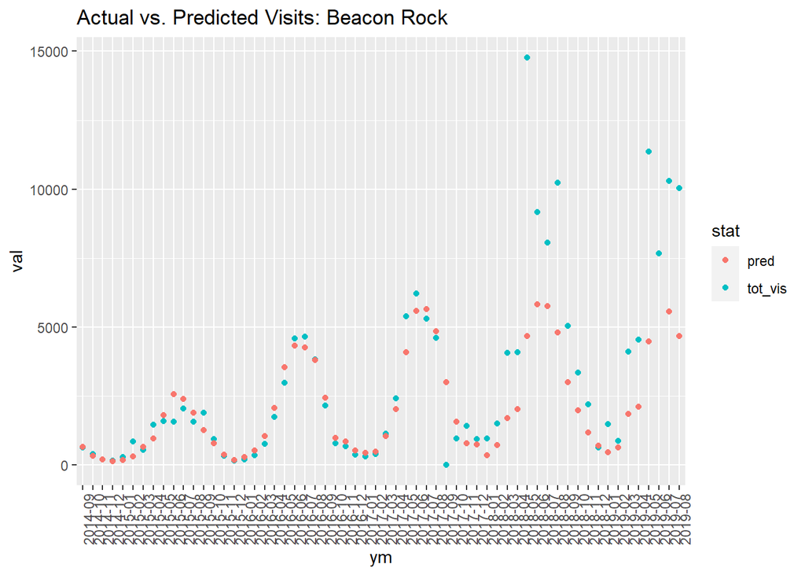

```r
beaconrock <- vc %>%
  filter(Name=="Beacon Rock") %>%
  select(year, month, Name, TAVG, PRCP, tot_vis) %>%
  mutate(monthchar = case_when(month < 10 ~ paste("0", as.character(month), sep=""),
                               month >=10 ~ as.character(month))) %>%
  mutate(ym = paste(as.character(year), monthchar,  sep="-")) %>%
  arrange(year, month) %>%
  mutate(year=as.factor(year),
         month = as.factor(month),
         Name = as.factor(Name))

beaconrock$year[beaconrock$year==2018 | beaconrock$year==2019] <- 2017
beaconrock$pred <- predict(m2, beaconrock, type="response")
brplot <- beaconrock %>%
  select(ym, tot_vis, pred) %>%
  pivot_longer(cols=c("tot_vis", "pred"), names_to="stat", values_to="val")

ggplot(brplot, aes(x=ym, y=val, col=stat, fill=stat)) +
  geom_point() +
  theme(axis.text.x = element_text(angle=90)) +
  ggtitle("Actual vs. Predicted Visits: Beacon Rock")
```

This plot obviously needs a ton of work, but you can see the basic story: Red points are predicted visits and blue points are actual visits. Prior to the fire, actual and predicted values track fairly well. After the fire, this trail saw a ton more visits than would have been predicted based on the weather in those years.

### Trail that had a ton of visits before the fire but closed : Eagle Creek

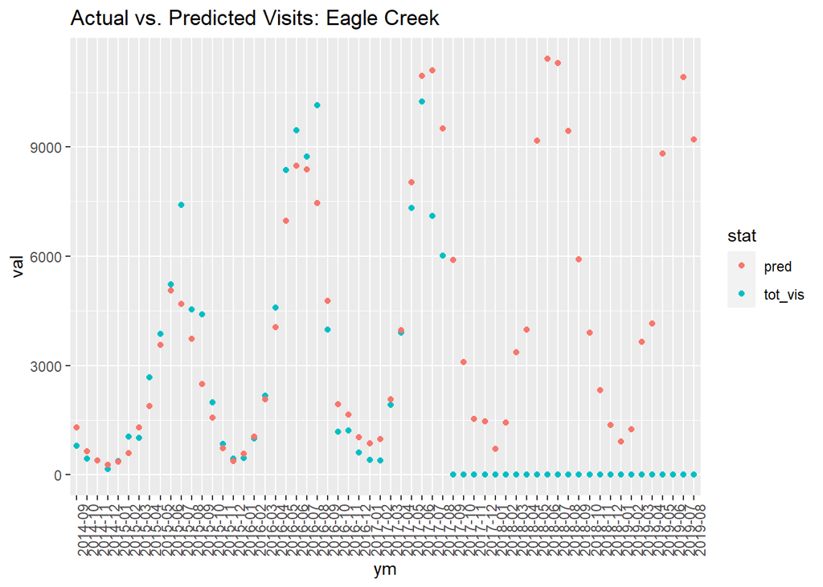

```r
ec <- vc %>%
  filter(Name=="Eagle Creek") %>%
  select(year, month, Name, TAVG, PRCP, tot_vis) %>%
  mutate(monthchar = case_when(month < 10 ~ paste("0", as.character(month), sep=""),
                               month >=10 ~ as.character(month))) %>%
  mutate(ym = paste(as.character(year), monthchar,  sep="-")) %>%
  arrange(year, month) %>%
  mutate(year=as.factor(year),
         month = as.factor(month),
         Name = as.factor(Name))

ec$year[ec$year==2018 | ec$year==2019] <- 2017
ec$pred <- predict(m2, ec, type="response")
ecplot <- ec %>%
  select(ym, tot_vis, pred) %>%
  pivot_longer(cols=c("tot_vis", "pred"), names_to="stat", values_to="val")

ggplot(ecplot, aes(x=ym, y=val, col=stat, fill=stat)) +
  geom_point() +
  theme(axis.text.x = element_text(angle=90)) +
  ggtitle("Actual vs. Predicted Visits: Eagle Creek")
```

Another ugly plot, but you can see that predicted visits were way higher afterthe fire than actual visits (which were zero, because the trail was closed).

### Trail that closed but reopened: Angel’s Rest Trail

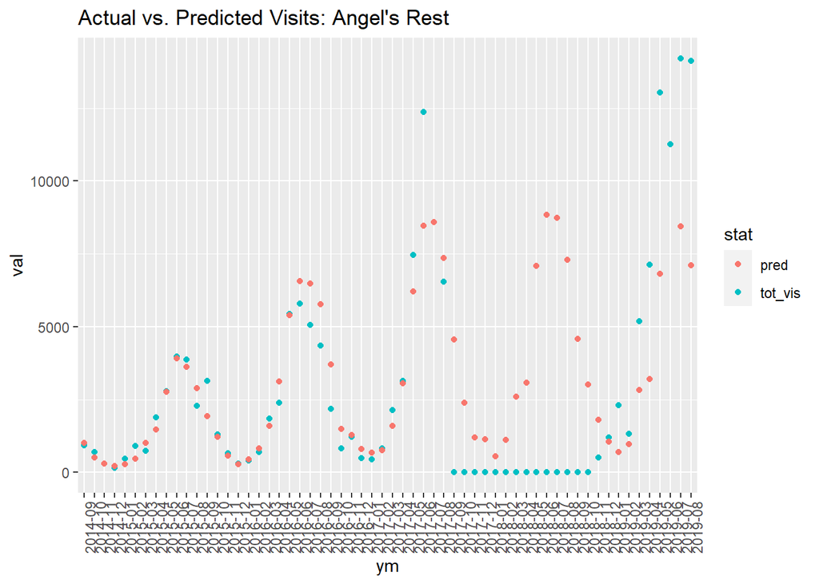

```r
ar <- vc %>%
  filter(Name=="Angels rest trail") %>%
  select(year, month, Name, TAVG, PRCP, tot_vis) %>%
  mutate(monthchar = case_when(month < 10 ~ paste("0", as.character(month), sep=""),
                               month >=10 ~ as.character(month))) %>%
  mutate(ym = paste(as.character(year), monthchar,  sep="-")) %>%
  arrange(year, month) %>%
  mutate(year=as.factor(year),
         month = as.factor(month),
         Name = as.factor(Name))

ar$year[ar$year==2018 | ar$year==2019] <- 2017
ar$pred <- predict(m2, ar, type="response")
arplot <- ar %>%
  select(ym, tot_vis, pred) %>%
  pivot_longer(cols=c("tot_vis", "pred"), names_to="stat", values_to="val")

ggplot(arplot, aes(x=ym, y=val, col=stat, fill=stat)) +
  geom_point() +
  theme(axis.text.x = element_text(angle=90)) +
  ggtitle("Actual vs. Predicted Visits: Angel's Rest")
```

While Angel’s Rest was closed for a bit, visits rebounded quickly once the trail reopened, surpassing predicted counts.

## Still to do:

- Test model fit using different specifications and combinations of climate variables to see which ones generate the best fit
- Visualize predictions!